# Final Assignment

Task B.1 — Time-Series Exploration

```python
df = pd.read_csv("iot_telemetry_data_cleaned.csv", parse_dates=["ts"])
df.head()
```

|  | ts | device | co | humidity | light | lpg | motion | smoke | temp | hour | date | device_encoded | temp_scaled | humidity_scaled | co_scaled | smoke_scaled | lpg_scaled |
| --- | --- | --- | --- | --- | --- | --- | --- | --- | --- | --- | --- | --- | --- | --- | --- | --- | --- |
| 0 | 2020-07-12 00:01:34.385974646 | b8:27:eb:bf:9d:51 | 0.004956 | 51.000000 | False | 0.007651 | False | 0.020411 | 22.700000 | 0 | 2020-07-12 | 2 | 0.090970 | -0.844720 | 0.279703 | 0.302605 | 0.307344 |
| 1 | 2020-07-12 00:01:34.735567570 | 00:0f:00:70:91:0a | 0.002840 | 76.000000 | False | 0.005114 | False | 0.013275 | 19.700001 | 0 | 2020-07-12 | 0 | -1.042023 | 1.388682 | -1.503582 | -1.516787 | -1.518658 |
| 2 | 2020-07-12 00:01:38.073572874 | b8:27:eb:bf:9d:51 | 0.004976 | 50.900000 | False | 0.007673 | False | 0.020475 | 22.600000 | 0 | 2020-07-12 | 2 | 0.053204 | -0.853654 | 0.296622 | 0.318884 | 0.323474 |
| 3 | 2020-07-12 00:01:39.589145899 | 1c:bf:ce:15:ec:4d | 0.004403 | 76.800003 | True | 0.007023 | False | 0.018628 | 27.000000 | 0 | 2020-07-12 | 1 | 1.714927 | 1.460151 | -0.186303 | -0.151972 | -0.144387 |
| 4 | 2020-07-12 00:01:41.761234999 | b8:27:eb:bf:9d:51 | 0.004967 | 50.900000 | False | 0.007664 | False | 0.020448 | 22.600000 | 0 | 2020-07-12 | 2 | 0.053204 | -0.853654 | 0.289332 | 0.311872 | 0.316527 |

B.1.2 Global time-series overview

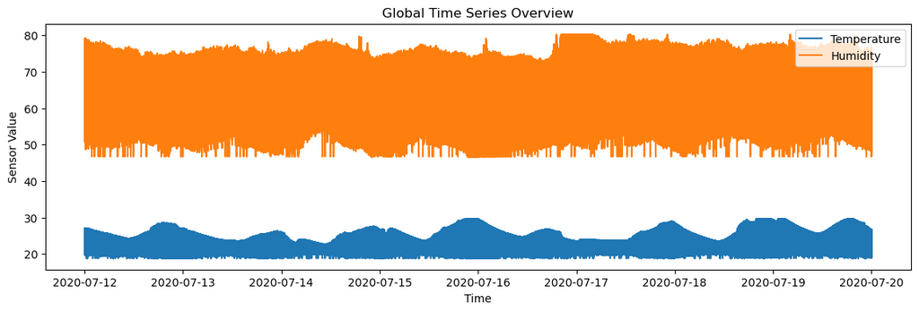

```python
plt.figure(figsize=(14, 4))
plt.plot(df["ts"], df["temp"], label="Temperature")
plt.plot(df["ts"], df["humidity"], label="Humidity")
plt.title("Global Time Series Overview")
plt.xlabel("Time")
plt.ylabel("Sensor Value")
plt.legend()
plt.show()
```

B.1.3 Rolling average

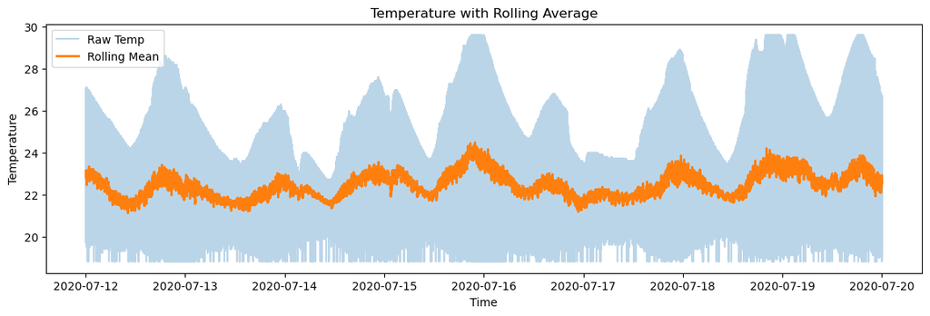

```python
window = 100  # number of samples

plt.figure(figsize=(14, 4))
plt.plot(df["ts"], df["temp"], alpha=0.3, label="Raw Temp")
plt.plot(df["ts"], df["temp"].rolling(window).mean(),
         linewidth=2, label="Rolling Mean")
plt.title("Temperature with Rolling Average")
plt.xlabel("Time")
plt.ylabel("Temperature")
plt.legend()
plt.show()
```

B.1.4 Daily pattern analysis

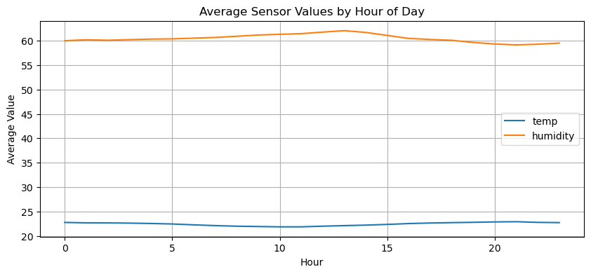

```python
df["hour"] = df["ts"].dt.hour

hourly_avg = df.groupby("hour")[["temp", "humidity"]].mean()

hourly_avg.plot(figsize=(10, 4))
plt.title("Average Sensor Values by Hour of Day")
plt.xlabel("Hour")
plt.ylabel("Average Value")
plt.grid(True)
plt.show()
```

B.1.5 Device-level time-series comparison

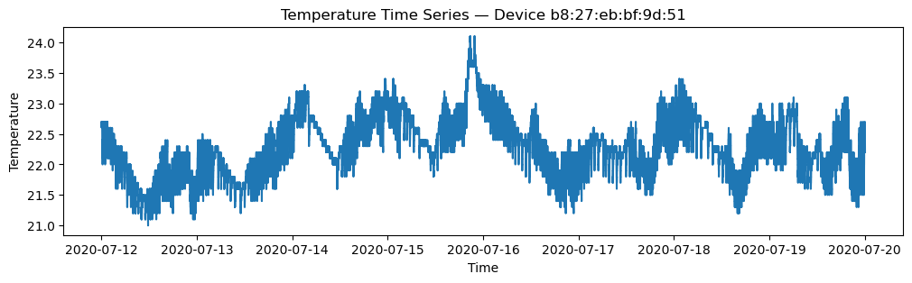

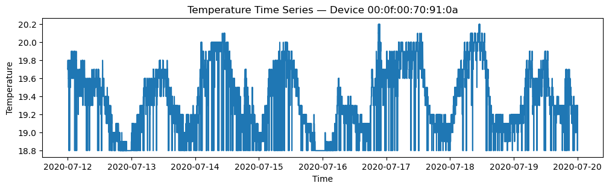

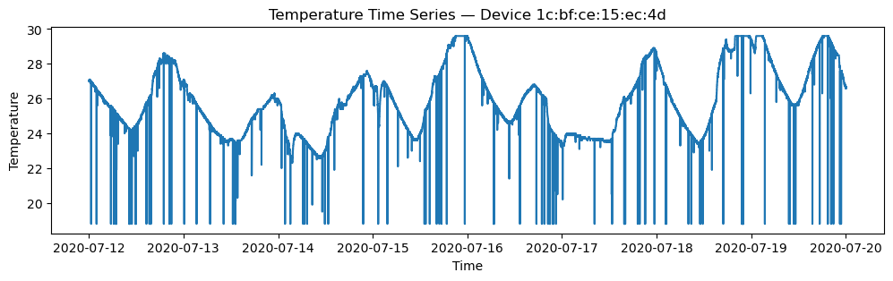

```python
devices = df["device"].unique()

for device in devices:
    subset = df[df["device"] == device]

    plt.figure(figsize=(12, 3))
    plt.plot(subset["ts"], subset["temp"])
    plt.title(f"Temperature Time Series — Device {device}")
    plt.xlabel("Time")
    plt.ylabel("Temperature")
    plt.show()
```

B.1.6 Event behavior over time

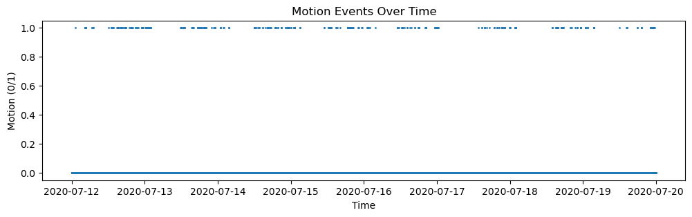

```python
plt.figure(figsize=(12, 3))
plt.scatter(df["ts"], df["motion"], s=1)
plt.title("Motion Events Over Time")
plt.xlabel("Time")
plt.ylabel("Motion (0/1)")
plt.show()
```

Light state timeline

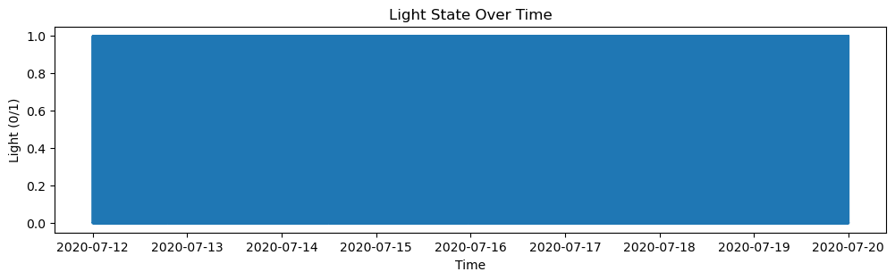

```python
plt.figure(figsize=(12, 3))
plt.step(df["ts"], df["light"], where="post")
plt.title("Light State Over Time")
plt.xlabel("Time")
plt.ylabel("Light (0/1)")
plt.show()
```

Task B.2 — Correlation & Relationship Analysis

```python
analysis_cols = ["temp", "humidity", "co", "smoke", "lpg", "motion", "light"]
df_analysis = df[analysis_cols]
```

B.2.2 Correlation matrix

```python
corr_matrix = df_analysis.corr()
corr_matrix
```

|  | temp | humidity | co | smoke | lpg | motion | light |
| --- | --- | --- | --- | --- | --- | --- | --- |
| temp | 1.000000 | -0.423632 | 0.135302 | 0.152853 | 0.156657 | 0.038130 | 0.758698 |
| humidity | -0.423632 | 1.000000 | -0.714120 | -0.717374 | -0.717763 | -0.010842 | 0.071678 |
| co | 0.135302 | -0.714120 | 1.000000 | 0.998943 | 0.998420 | -0.000314 | -0.234835 |
| smoke | 0.152853 | -0.717374 | 0.998943 | 1.000000 | 0.999948 | 0.000411 | -0.215661 |
| lpg | 0.156657 | -0.717763 | 0.998420 | 0.999948 | 1.000000 | 0.000570 | -0.211313 |
| motion | 0.038130 | -0.010842 | -0.000314 | 0.000411 | 0.000570 | 1.000000 | 0.033594 |
| light | 0.758698 | 0.071678 | -0.234835 | -0.215661 | -0.211313 | 0.033594 | 1.000000 |

B.2.3 Correlation heatmap

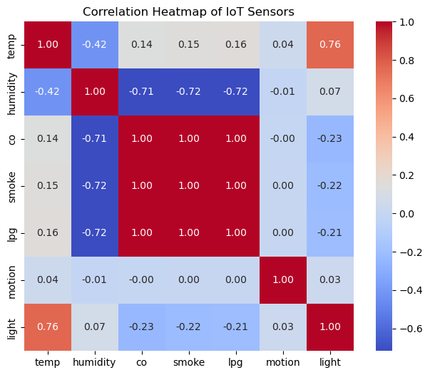

```python
plt.figure(figsize=(8, 6))
sns.heatmap(
    corr_matrix,
    annot=True,
    fmt=".2f",
    cmap="coolwarm",
    square=True
)
plt.title("Correlation Heatmap of IoT Sensors")
plt.show()
```

B.2.4 Focused sensor–sensor relationships

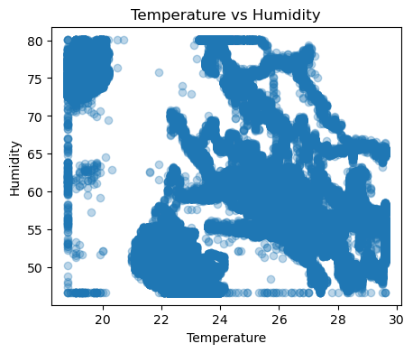

```python
plt.figure(figsize=(5, 4))
plt.scatter(df["temp"], df["humidity"], alpha=0.3)
plt.xlabel("Temperature")
plt.ylabel("Humidity")
plt.title("Temperature vs Humidity")
plt.show()
```

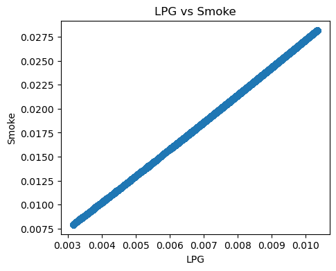

```python
#LPG vs Smoke
plt.figure(figsize=(5, 4))
plt.scatter(df["lpg"], df["smoke"], alpha=0.3)
plt.xlabel("LPG")
plt.ylabel("Smoke")
plt.title("LPG vs Smoke")
plt.show()
```

B.2.5 Event–sensor relationship analysis

```python
motion_temp = df.groupby("motion")["temp"].mean()
motion_temp
```

```
motion
False    22.455640
True     25.384647
Name: temp, dtype: float64
```

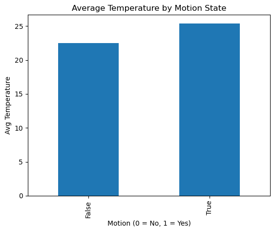

```python
motion_temp.plot(kind="bar")
plt.title("Average Temperature by Motion State")
plt.xlabel("Motion (0 = No, 1 = Yes)")
plt.ylabel("Avg Temperature")
plt.show()
```

```python
#Light vs Sensor behavior
light_stats = df.groupby("light")[["temp", "humidity"]].mean()
light_stats
```

| light | temp | humidity |
| --- | --- | --- |
| False | 21.213429 | 59.958018 |
| True | 25.698895 | 61.749455 |

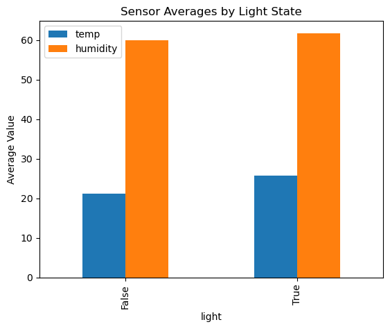

```python
light_stats.plot(kind="bar")
plt.title("Sensor Averages by Light State")
plt.ylabel("Average Value")
plt.show()
```

B.2.6 Multicollinearity warning

```python
high_corr_pairs = (
    corr_matrix
    .where(np.triu(np.ones(corr_matrix.shape), k=1).astype(bool))
    .stack()
    .sort_values(ascending=False)
)

high_corr_pairs[abs(high_corr_pairs) > 0.7]
```

```
smoke     lpg      0.999948
co        smoke    0.998943
          lpg      0.998420
temp      light    0.758698
humidity  co      -0.714120
          smoke   -0.717374
          lpg     -0.717763
dtype: float64
```

Task B.3 — Advanced Visualization & Pattern Discovery

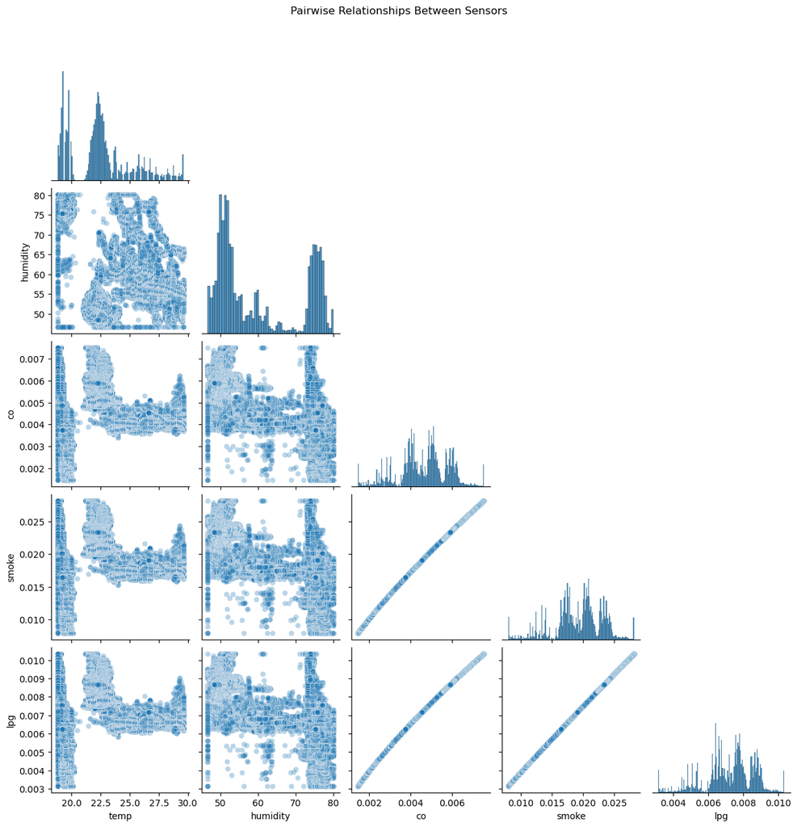

```python
sns.pairplot(
    df[["temp", "humidity", "co", "smoke", "lpg"]],
    corner=True,
    plot_kws={"alpha": 0.3}
)
plt.suptitle("Pairwise Relationships Between Sensors", y=1.02)
plt.show()
```

B.3.2 Time–hour heatmap

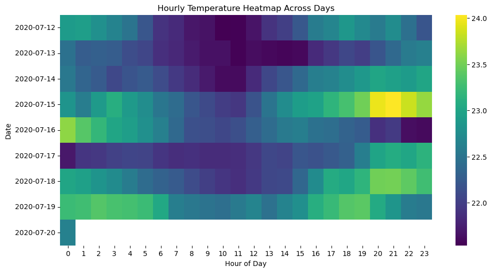

```python
df["date"] = df["ts"].dt.date
df["hour"] = df["ts"].dt.hour

hourly_temp = df.pivot_table(
    values="temp",
    index="date",
    columns="hour",
    aggfunc="mean"
)

plt.figure(figsize=(12, 6))
sns.heatmap(hourly_temp, cmap="viridis")
plt.title("Hourly Temperature Heatmap Across Days")
plt.xlabel("Hour of Day")
plt.ylabel("Date")
plt.show()
```

B.3.3 Event density over time

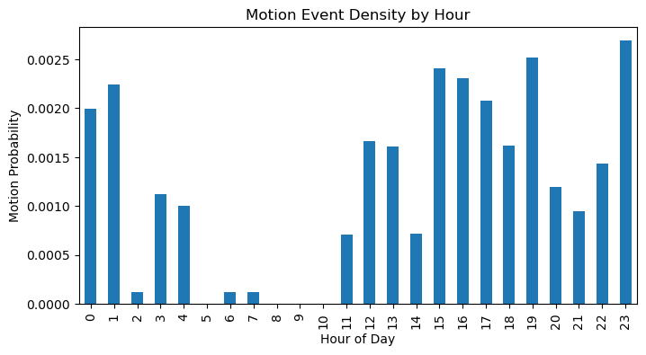

```python
motion_density = df.groupby("hour")["motion"].mean()

motion_density.plot(kind="bar", figsize=(8, 4))
plt.title("Motion Event Density by Hour")
plt.xlabel("Hour of Day")
plt.ylabel("Motion Probability")
plt.show()
```

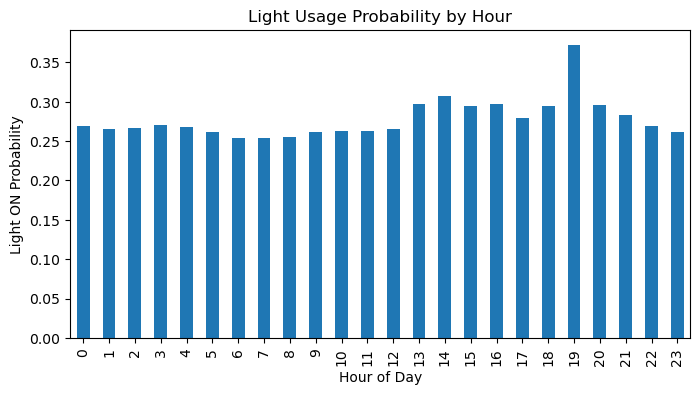

```python
#Light usage pattern
light_density = df.groupby("hour")["light"].mean()

light_density.plot(kind="bar", figsize=(8, 4))
plt.title("Light Usage Probability by Hour")
plt.xlabel("Hour of Day")
plt.ylabel("Light ON Probability")
plt.show()
```

B.3.4 Sensor distributions by device

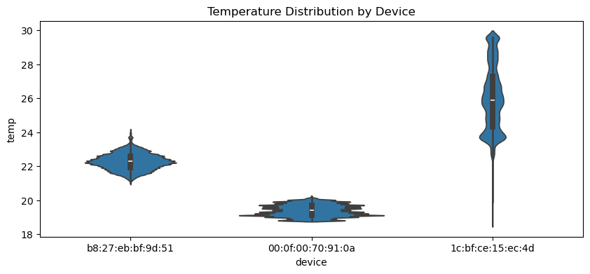

```python
plt.figure(figsize=(10, 4))
sns.violinplot(data=df, x="device", y="temp")
plt.title("Temperature Distribution by Device")
plt.show()
```

B.3.5 Gas sensor interaction

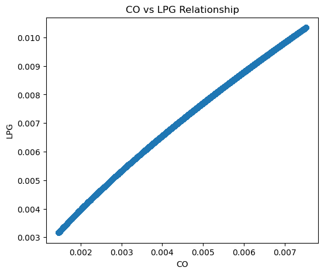

```python
plt.figure(figsize=(6, 5))
plt.scatter(df["co"], df["lpg"], alpha=0.3)
plt.xlabel("CO")
plt.ylabel("LPG")
plt.title("CO vs LPG Relationship")
plt.show()
```

B.3.6 Feature interaction via color encoding

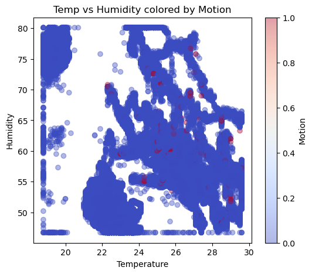

```python
plt.figure(figsize=(6, 5))
plt.scatter(
    df["temp"],
    df["humidity"],
    c=df["motion"],
    cmap="coolwarm",
    alpha=0.4
)
plt.colorbar(label="Motion")
plt.xlabel("Temperature")
plt.ylabel("Humidity")
plt.title("Temp vs Humidity colored by Motion")
plt.show()
```

Task C.1 — Event Definition & Basic Probability

```python
temp_threshold = df["temp"].quantile(0.75)
lpg_threshold = df["lpg"].quantile(0.75)

temp_threshold, lpg_threshold
```

```
(23.600000381469727, 0.0081504433910493)
```

C.1.2 Create event indicator columns

```python
df["high_temp"] = (df["temp"] > temp_threshold).astype(int)
df["high_lpg"] = (df["lpg"] > lpg_threshold).astype(int)
```

C.1.3 Probability of basic events

```python
p_motion = df["motion"].mean()
p_motion
```

```
0.0011895830042647291
```

```python
#P(Light ON)
p_light = df["light"].mean()
p_light
```

```
0.27771827120518083
```

```python
#P(High Temperature)
p_high_temp = df["high_temp"].mean()
p_high_temp
```

```
0.23722062075501502
```

```python
#P(High LPG)
p_high_lpg = df["high_lpg"].mean()
p_high_lpg
```

```
0.24993336360764493
```

C.1.4 Joint probabilities

```python
p_motion_and_light = ((df["motion"] == 1) & (df["light"] == 1)).mean()
p_motion_and_light
```

```
0.0008489969988943295
```

```python
#P(High Temp AND Motion)
p_high_temp_and_motion = ((df["high_temp"] == 1) & (df["motion"] == 1)).mean()
p_high_temp_and_motion
```

```
0.0007453403885642079
```

C.1.5 Visualize event probabilities

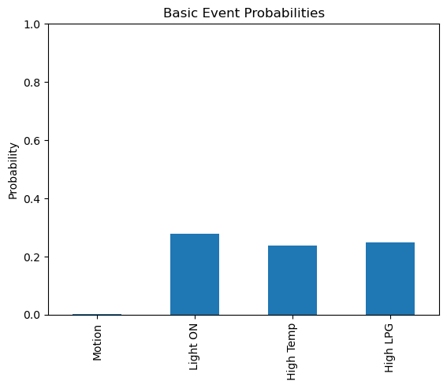

```python
event_probs = {
    "Motion": p_motion,
    "Light ON": p_light,
    "High Temp": p_high_temp,
    "High LPG": p_high_lpg
}

pd.Series(event_probs).plot(kind="bar")
plt.title("Basic Event Probabilities")
plt.ylabel("Probability")
plt.ylim(0, 1)
plt.show()
```

C.1.6 Device-level probability comparison

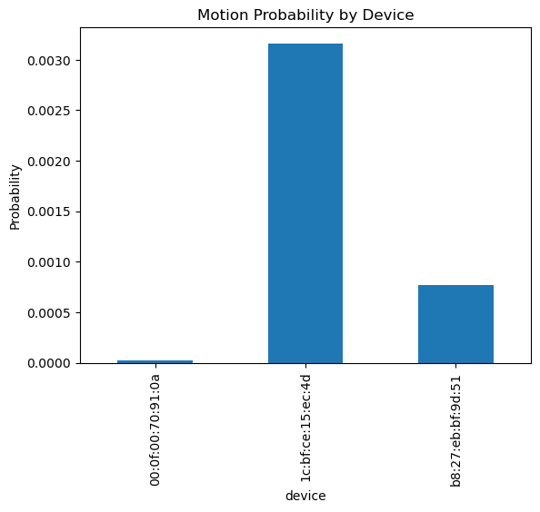

```python
device_motion_prob = df.groupby("device")["motion"].mean()
device_motion_prob
device_motion_prob.plot(kind="bar")
plt.title("Motion Probability by Device")
plt.ylabel("Probability")
plt.show()
```

Task C.2 — Conditional Probability & Bayes Interpretation

```python
#C.2.2 P(Motion | Light)

p_motion_given_light = (
    ((df["motion"] == 1) & (df["light"] == 1)).mean()
    / df["light"].mean()
)

p_motion_given_light
```

```
0.003057044087196851
```

C.2.3 P(Light | Motion)

```python
p_light_given_motion = (
    ((df["light"] == 1) & (df["motion"] == 1)).mean()
    / df["motion"].mean()
)

p_light_given_motion
```

```
0.7136929460580913
```

C.2.4 P(High Temperature | Motion)

```python
p_high_temp_given_motion = (
    ((df["high_temp"] == 1) & (df["motion"] == 1)).mean()
    / df["motion"].mean()
)

p_high_temp_given_motion
```

```
0.6265560165975104
```

C.2.5 P(Motion | High Temperature)

```python
p_motion_given_high_temp = (
    ((df["motion"] == 1) & (df["high_temp"] == 1)).mean()
    / df["high_temp"].mean()
)

p_motion_given_high_temp
```

```
0.003141971326910672
```

C.2.6 Bayes’ rule verification (empirical)

```python
bayes_motion_given_light = (
    p_light_given_motion * p_motion / p_light
)

bayes_motion_given_light
```

```
0.003057044087196851
```

```python
print("Direct computation :", p_motion_given_light)
print("Bayes computation  :", bayes_motion_given_light)
```

```
Direct computation : 0.003057044087196851
Bayes computation  : 0.003057044087196851
```

C.2.7 Conditional probability table (confusion-style)

```python
contingency_table = pd.crosstab(
    df["motion"],
    df["light"],
    normalize="all"
)

contingency_table
```

| light motion | False | True |
| --- | --- | --- |
| False | 0.721941 | 0.276869 |
| True | 0.000341 | 0.000849 |

C.2.8 Visualize conditional probabilities

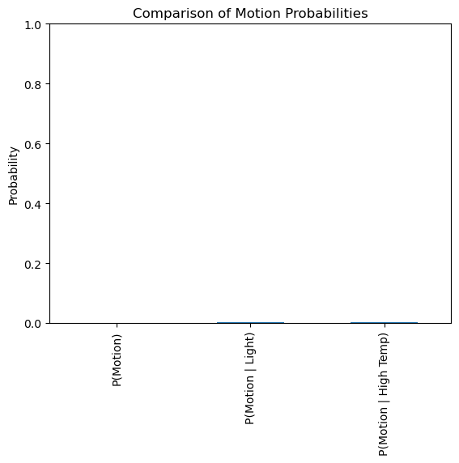

```python
conditional_probs = pd.DataFrame({
    "P(Motion)": [p_motion],
    "P(Motion | Light)": [p_motion_given_light],
    "P(Motion | High Temp)": [p_motion_given_high_temp]
})

conditional_probs.T.plot(kind="bar", legend=False)
plt.ylabel("Probability")
plt.title("Comparison of Motion Probabilities")
plt.ylim(0, 1)
plt.show()
```

Task C.3 — Independence Testing & Event Relationships

```python
p_motion = df["motion"].mean()
p_light = df["light"].mean()

p_motion_and_light = ((df["motion"] == 1) & (df["light"] == 1)).mean()

print("P(Motion ∩ Light):", p_motion_and_light)
print("P(Motion) × P(Light):", p_motion * p_light)
```

```
P(Motion ∩ Light): 0.0008489969988943295
P(Motion) × P(Light): 0.00033036893539946583
```

```python
#Contingency table (counts)
contingency_counts = pd.crosstab(df["motion"], df["light"])
contingency_counts
```

| light motion | False | True |
| --- | --- | --- |
| False | 292519 | 112183 |
| True | 138 | 344 |

```python
#Chi-square test of independence
from scipy.stats import chi2_contingency

chi2, p_value, dof, expected = chi2_contingency(contingency_counts)

chi2, p_value, dof
```

```
(455.09939924460343, 5.602204099646896e-101, 1)
```

```python
#Interpret the result (VERY IMPORTANT)
alpha = 0.05

if p_value < alpha:
    print("Reject H0: Motion and Light are NOT independent")
else:
    print("Fail to reject H0: Motion and Light may be independent")
```

```
Reject H0: Motion and Light are NOT independent
```

```python
#Independence test: Motion vs High Temperature
contingency_temp = pd.crosstab(df["motion"], df["high_temp"])

chi2_t, p_t, _, _ = chi2_contingency(contingency_temp)

p_t
```

```
1.9142192191408372e-89
```

```python
if p_t < alpha:
    print("Motion and High Temperature are dependent")
else:
    print("Motion and High Temperature appear independent")
```

```
Motion and High Temperature are dependent
```

Task D.1 — Law of Large Numbers (LLN)

```python
data = df["temp"].values
true_mean = data.mean()

true_mean
```

```
22.459124756525938
```

```python
running_mean = np.cumsum(data) / np.arange(1, len(data) + 1)
```

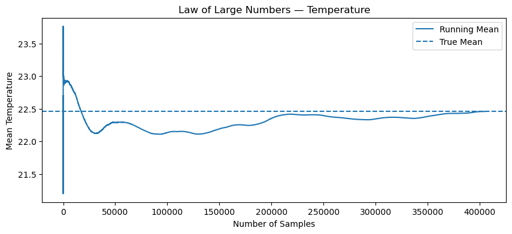

```python
plt.figure(figsize=(10, 4))
plt.plot(running_mean, label="Running Mean")
plt.axhline(true_mean, linestyle="--", label="True Mean")
plt.title("Law of Large Numbers — Temperature")
plt.xlabel("Number of Samples")
plt.ylabel("Mean Temperature")
plt.legend()
plt.show()
```

```python
motion_data = df["motion"].values
true_prob = motion_data.mean()

running_prob = np.cumsum(motion_data) / np.arange(1, len(motion_data) + 1)

true_prob
```

```
0.0011895830042647291
```

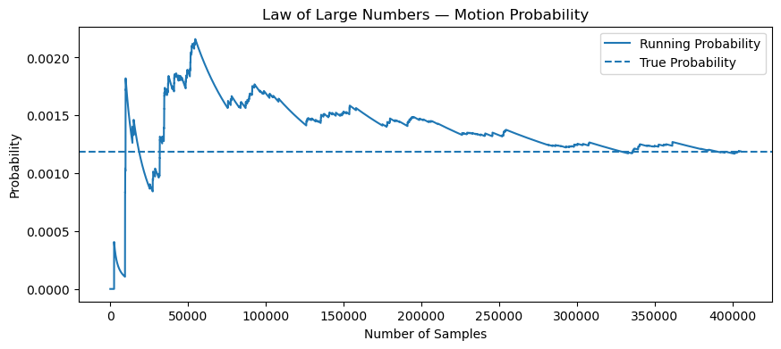

```python
plt.figure(figsize=(10, 4))
plt.plot(running_prob, label="Running Probability")
plt.axhline(true_prob, linestyle="--", label="True Probability")
plt.title("Law of Large Numbers — Motion Probability")
plt.xlabel("Number of Samples")
plt.ylabel("Probability")
plt.legend()
plt.show()
```

Task D.2 — Central Limit Theorem (CLT)

```python
data = df["temp"].values
np.random.seed(42)  # reproducibility

sample_size = 50       # size of each sample
num_samples = 1000     # number of samples

sample_means = []

for _ in range(num_samples):
    sample = np.random.choice(data, size=sample_size, replace=True)
    sample_means.append(sample.mean())

sample_means = np.array(sample_means)
```

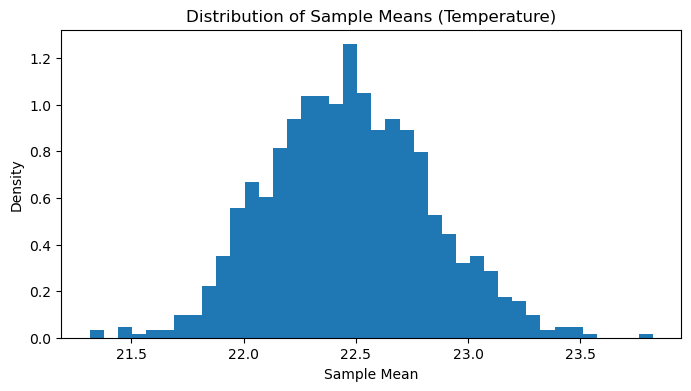

```python
#Visualize distribution of sample means
plt.figure(figsize=(8, 4))
plt.hist(sample_means, bins=40, density=True)
plt.title("Distribution of Sample Means (Temperature)")
plt.xlabel("Sample Mean")
plt.ylabel("Density")
plt.show()
```

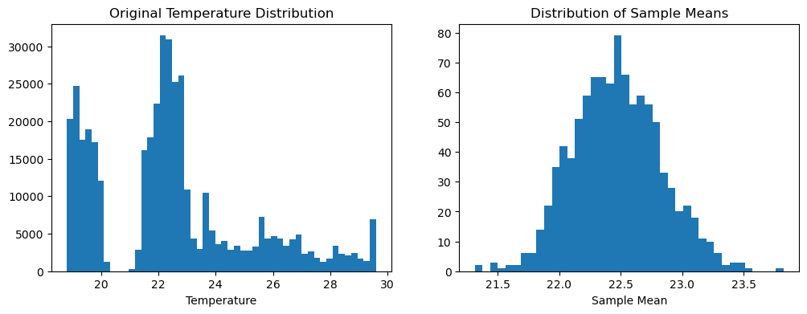

```python
#Compare with original distribution
plt.figure(figsize=(12, 4))

plt.subplot(1, 2, 1)
plt.hist(data, bins=50)
plt.title("Original Temperature Distribution")
plt.xlabel("Temperature")

plt.subplot(1, 2, 2)
plt.hist(sample_means, bins=40)
plt.title("Distribution of Sample Means")
plt.xlabel("Sample Mean")

plt.show()
```

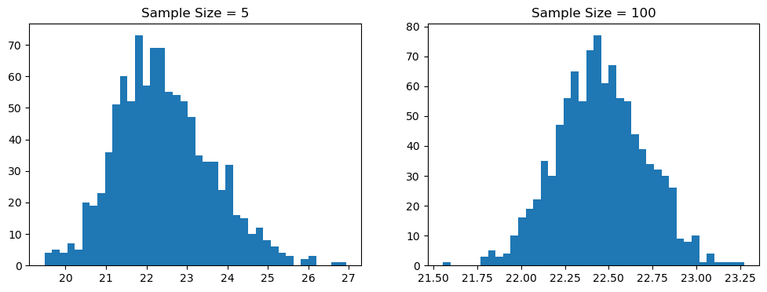

```python
#Effect of sample size (small vs large)
def generate_sample_means(data, sample_size, num_samples=1000):
    return [
        np.random.choice(data, size=sample_size, replace=True).mean()
        for _ in range(num_samples)
    ]
means_small = generate_sample_means(data, sample_size=5)
means_large = generate_sample_means(data, sample_size=100)
plt.figure(figsize=(12, 4))

plt.subplot(1, 2, 1)
plt.hist(means_small, bins=40)
plt.title("Sample Size = 5")

plt.subplot(1, 2, 2)
plt.hist(means_large, bins=40)
plt.title("Sample Size = 100")

plt.show()
```

Task D.3 — Statistical Confidence & Estimation

```python
#Confidence interval for mean (temperature)
from scipy import stats
temp_data = df["temp"].values
n = len(temp_data)
mean_temp = temp_data.mean()
std_temp = temp_data.std(ddof=1)

confidence = 0.95
alpha = 1 - confidence

t_critical = stats.t.ppf(1 - alpha/2, df=n-1)

ci_lower = mean_temp - t_critical * std_temp / np.sqrt(n)
ci_upper = mean_temp + t_critical * std_temp / np.sqrt(n)

mean_temp, ci_lower, ci_upper
```

```
(22.459124756525938, 22.450971749868604, 22.467277763183272)
```

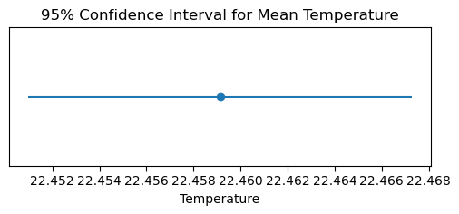

```python
#Visualize confidence interval
plt.figure(figsize=(6, 2))
plt.errorbar(mean_temp, 0, xerr=[[mean_temp - ci_lower], [ci_upper - mean_temp]],
             fmt='o')
plt.yticks([])
plt.title("95% Confidence Interval for Mean Temperature")
plt.xlabel("Temperature")
plt.show()
```

```python
#Confidence interval for probability (motion)
p_hat = df["motion"].mean()
n = len(df)

z = stats.norm.ppf(0.975)  # 95% CI

ci_lower_p = p_hat - z * np.sqrt((p_hat * (1 - p_hat)) / n)
ci_upper_p = p_hat + z * np.sqrt((p_hat * (1 - p_hat)) / n)

p_hat, ci_lower_p, ci_upper_p
```

```
(0.0011895830042647291, 0.0010834474592952969, 0.0012957185492341614)
```

Task E.1 — Problem Definition & Feature Selection

```python
target = "temp"
feature_cols = [
    "humidity",
    "co",
    "smoke",
    "lpg",
    "motion",
    "light",
    "device_encoded"
]
X = df[feature_cols]
y = df[target]

X.head(), y.head()
```

```
(    humidity        co     smoke       lpg  motion  light  device_encoded
 0  51.000000  0.004956  0.020411  0.007651   False  False               2
 1  76.000000  0.002840  0.013275  0.005114   False  False               0
 2  50.900000  0.004976  0.020475  0.007673   False  False               2
 3  76.800003  0.004403  0.018628  0.007023   False   True               1
 4  50.900000  0.004967  0.020448  0.007664   False  False               2,
 0    22.700000
 1    19.700001
 2    22.600000
 3    27.000000
 4    22.600000
 Name: temp, dtype: float64)
```

```python
X.describe().T
```

|  | count | mean | std | min | 25% | 50% | 75% | max |
| --- | --- | --- | --- | --- | --- | --- | --- | --- |
| humidity | 405184.0 | 60.455533 | 11.193698 | 46.700000 | 51.000000 | 54.900000 | 74.300003 | 80.099998 |
| co | 405184.0 | 0.004624 | 0.001186 | 0.001463 | 0.003919 | 0.004812 | 0.005409 | 0.007518 |
| smoke | 405184.0 | 0.019224 | 0.003922 | 0.007952 | 0.017024 | 0.019950 | 0.021838 | 0.028165 |
| lpg | 405184.0 | 0.007224 | 0.001389 | 0.003165 | 0.006456 | 0.007489 | 0.008150 | 0.010342 |
| device_encoded | 405184.0 | 1.186671 | 0.838897 | 0.000000 | 0.000000 | 1.000000 | 2.000000 | 2.000000 |

```python
split_ratio = 0.8
split_index = int(len(df) * split_ratio)

X_train = X.iloc[:split_index]
X_test  = X.iloc[split_index:]

y_train = y.iloc[:split_index]
y_test  = y.iloc[split_index:]

len(X_train), len(X_test)
```

```
(324147, 81037)
```

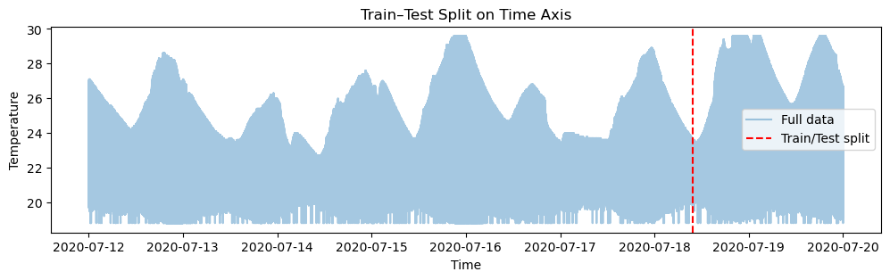

```python
#Visualize train–test split
plt.figure(figsize=(12, 3))
plt.plot(df["ts"], y, label="Full data", alpha=0.4)
plt.axvline(df["ts"].iloc[split_index], color="red", linestyle="--", label="Train/Test split")
plt.title("Train–Test Split on Time Axis")
plt.xlabel("Time")
plt.ylabel("Temperature")
plt.legend()
plt.show()
```

Task E.2 — Baseline Model (Linear Regression)

```python
from sklearn.linear_model import LinearRegression
from sklearn.metrics import mean_absolute_error, mean_squared_error, r2_score
lin_reg = LinearRegression()
lin_reg.fit(X_train, y_train)
y_train_pred = lin_reg.predict(X_train)
y_test_pred = lin_reg.predict(X_test)
```

```python
def regression_metrics(y_true, y_pred):
    mae = mean_absolute_error(y_true, y_pred)
    rmse = np.sqrt(mean_squared_error(y_true, y_pred))
    r2 = r2_score(y_true, y_pred)
    return mae, rmse, r2
```

```python
train_mae, train_rmse, train_r2 = regression_metrics(y_train, y_train_pred)
test_mae, test_rmse, test_r2 = regression_metrics(y_test, y_test_pred)

print("TRAIN:")
print("MAE :", train_mae)
print("RMSE:", train_rmse)
print("R²  :", train_r2)

print("\nTEST:")
print("MAE :", test_mae)
print("RMSE:", test_rmse)
print("R²  :", test_r2)
```

```
TRAIN:
MAE : 0.654414213751876
RMSE: 1.0664848783486005
R²  : 0.813703827361369

TEST:
MAE : 0.8852201536155906
RMSE: 1.533097580312959
R²  : 0.775330055133507
```

```python
pd.DataFrame({
    "Train": [train_mae, train_rmse, train_r2],
    "Test":  [test_mae, test_rmse, test_r2]
}, index=["MAE", "RMSE", "R²"])
```

|  | Train | Test |
| --- | --- | --- |
| MAE | 0.654414 | 0.885220 |
| RMSE | 1.066485 | 1.533098 |
| R² | 0.813704 | 0.775330 |

```python
coef_df = pd.DataFrame({
    "Feature": feature_cols,
    "Coefficient": lin_reg.coef_
}).sort_values(by="Coefficient", ascending=False)

coef_df
```

|  | Feature | Coefficient |
| --- | --- | --- |
| 3 | lpg | 54903.254120 |
| 1 | co | 13323.963890 |
| 5 | light | 4.232186 |
| 6 | device_encoded | 0.573563 |
| 4 | motion | 0.489192 |
| 0 | humidity | -0.089064 |
| 2 | smoke | -23531.330232 |

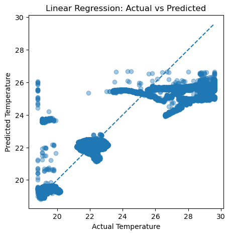

```python
plt.figure(figsize=(5, 5))
plt.scatter(y_test, y_test_pred, alpha=0.4)
plt.plot([y_test.min(), y_test.max()],
         [y_test.min(), y_test.max()],
         linestyle="--")
plt.xlabel("Actual Temperature")
plt.ylabel("Predicted Temperature")
plt.title("Linear Regression: Actual vs Predicted")
plt.show()
```

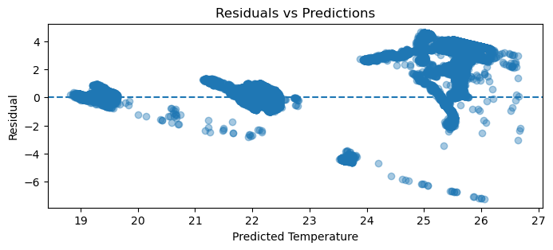

```python
residuals = y_test - y_test_pred

plt.figure(figsize=(8, 3))
plt.scatter(y_test_pred, residuals, alpha=0.4)
plt.axhline(0, linestyle="--")
plt.xlabel("Predicted Temperature")
plt.ylabel("Residual")
plt.title("Residuals vs Predictions")
plt.show()
```

Task E.3 — Regularized Models (Ridge & Lasso)

```python
from sklearn.linear_model import Ridge, Lasso
ridge = Ridge(alpha=1.0)
ridge.fit(X_train, y_train)
y_test_pred_ridge = ridge.predict(X_test)
ridge_mae, ridge_rmse, ridge_r2 = regression_metrics(y_test, y_test_pred_ridge)
ridge_mae, ridge_rmse, ridge_r2
```

```
(0.882191260408416, 1.5280258815434673, 0.7768140748785715)
```

Lasso Regression

```python
lasso = Lasso(alpha=0.01)
lasso.fit(X_train, y_train)
```

```
Lasso(alpha=0.01)
```